# COSC 3337 - Data Science

## Group 10: Alex, Jarrod, Thomas & Jerry

**1) Data Cleaning**

**Classification Goal: Predicting the outcome_type of a dog entering the shelter**

```
<class 'pandas.core.frame.DataFrame'>
RangeIndex: 79672 entries, 0 to 79671
Data columns (total 41 columns):
 #   Column                      Non-Null Count  Dtype
---  ------                      --------------  -----
 0   age_upon_outcome            79672 non-null  object
 1   animal_id_outcome           79672 non-null  object
 2   date_of_birth               79672 non-null  object
 3   outcome_subtype             36348 non-null  object
 4   outcome_type                79662 non-null  object
 5   sex_upon_outcome            79671 non-null  object
 6   age_upon_outcome_(days)     79672 non-null  int64
 7   age_upon_outcome_(years)    79672 non-null  float64
 8   age_upon_outcome_age_group  79672 non-null  object
 9   outcome_datetime            79672 non-null  object
```

[output cut: 33 more lines]

```
None
```

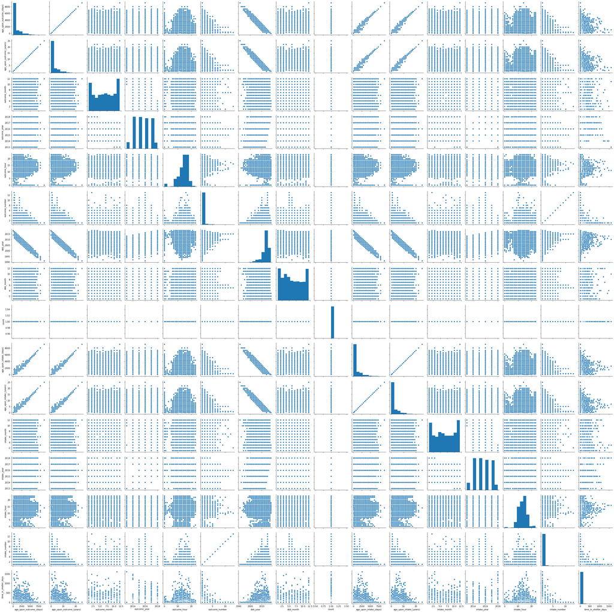

```python
import numpy as np
import pandas as pd
import seaborn as sb

acc1 = pd.read_csv("aac.csv")

display(acc1.info())
sb.pairplot(acc1)
```

**Filtering out attributes | Manually selected features based on pairplot and observation of feature definitions**

```python
acc2 = acc1.iloc[:,[4,21,22,23,25,26,27,30,33,36,40]]

display( acc2.info())
```

```
<class 'pandas.core.frame.DataFrame'>
RangeIndex: 79672 entries, 0 to 79671
Data columns (total 11 columns):
 #   Column                   Non-Null Count  Dtype
---  ------                   --------------  -----
 0   outcome_type             79662 non-null  object
 1   animal_type              79672 non-null  object
 2   breed                    79672 non-null  object
 3   color                    79672 non-null  object
 4   intake_condition         79672 non-null  object
 5   intake_type              79672 non-null  object
 6   sex_upon_intake          79671 non-null  object
 7   age_upon_intake_(years)  79672 non-null  float64
 8   intake_month             79672 non-null  int64
 9   intake_weekday           79672 non-null  object
 10  time_in_shelter_days     79672 non-null  float64
dtypes: float64(2), int64(1), object(8)
memory usage: 6.7+ MB
```

```
None
```

**Dropping nulls. Likely animals that were currently in the system (no outcome_type)**

```python
acc = pd.DataFrame(acc2.dropna().to_numpy(), columns=['outcome_type','animal_type','breed','color',
                                                      'intake_condition','intake_type',
                                                      'sex_upon_intake','age_upon_intake_years',
                                                      'intake_month','intake_weekday',
                                                      'time_in_shelter_days'])
display(acc.info())
```

```
<class 'pandas.core.frame.DataFrame'>
RangeIndex: 79661 entries, 0 to 79660
Data columns (total 11 columns):
 #   Column                 Non-Null Count  Dtype
---  ------                 --------------  -----
 0   outcome_type           79661 non-null  object
 1   animal_type            79661 non-null  object
 2   breed                  79661 non-null  object
 3   color                  79661 non-null  object
 4   intake_condition       79661 non-null  object
 5   intake_type            79661 non-null  object
 6   sex_upon_intake        79661 non-null  object
 7   age_upon_intake_years  79661 non-null  object
 8   intake_month           79661 non-null  object
 9   intake_weekday         79661 non-null  object
 10  time_in_shelter_days   79661 non-null  object
dtypes: object(11)
memory usage: 6.7+ MB
```

```
None
```

**Getting rid of all other animals | Looking for dogs only and making the rest NaN's to be dropped**

```python
acc.where(acc.iloc[:,[1]] == 'Dog', other=np.NaN, inplace=True, axis=None, level=None, errors='raise', try_cast=False)

display(acc.info())
acc
```

```
<class 'pandas.core.frame.DataFrame'>
RangeIndex: 79661 entries, 0 to 79660
Data columns (total 11 columns):
 #   Column                 Non-Null Count  Dtype
---  ------                 --------------  -----
 0   outcome_type           79661 non-null  object
 1   animal_type            45363 non-null  object
 2   breed                  79661 non-null  object
 3   color                  79661 non-null  object
 4   intake_condition       79661 non-null  object
 5   intake_type            79661 non-null  object
 6   sex_upon_intake        79661 non-null  object
 7   age_upon_intake_years  79661 non-null  object
 8   intake_month           79661 non-null  object
 9   intake_weekday         79661 non-null  object
 10  time_in_shelter_days   79661 non-null  object
dtypes: object(11)
memory usage: 6.7+ MB
```

```
None
```

|  | outcome_type | animal_type | breed | color | intake_condition | intake_type | sex_upon_intake | age_upon_intake_years | intake_month | intake_weekday | time_in_shelter_days |
| --- | --- | --- | --- | --- | --- | --- | --- | --- | --- | --- | --- |
| 0 | Return to Owner | Dog | Spinone Italiano Mix | Yellow/White | Normal | Stray | Neutered Male | 10 | 12 | Thursday | 0.588194 |
| 1 | Return to Owner | Dog | Spinone Italiano Mix | Yellow/White | Normal | Public Assist | Neutered Male | 7 | 12 | Friday | 1.25972 |
| 2 | Return to Owner | Dog | Spinone Italiano Mix | Yellow/White | Normal | Public Assist | Neutered Male | 6 | 3 | Friday | 1.11389 |
| 3 | Transfer | Dog | Dachshund | Tricolor | Normal | Owner Surrender | Neutered Male | 10 | 4 | Wednesday | 4.97014 |
| 4 | Return to Owner | Dog | Shetland Sheepdog | Brown/White | Injured | Public Assist | Neutered Male | 16 | 11 | Saturday | 0.119444 |
| ... | ... | ... | ... | ... | ... | ... | ... | ... | ... | ... | ... |
| 79656 | Transfer | NaN | Domestic Shorthair Mix | Tortie | Normal | Stray | Unknown | 0.0383562 | 3 | Thursday | 0.0770833 |
| 79657 | Euthanasia | NaN | Bat Mix | Brown | Normal | Wildlife | Unknown | 2 | 3 | Thursday | 0.0534722 |
| 79658 | Euthanasia | NaN | Bat Mix | Brown | Normal | Wildlife | Unknown | 1 | 3 | Thursday | 0.0479167 |
| 79659 | Return to Owner | Dog | Labrador Retriever Mix | Black/White | Normal | Stray | Intact Male | 0.410959 | 3 | Thursday | 1.7625 |
| 79660 | Euthanasia | Dog | Boxer Mix | Brown Brindle | Aged | Stray | Spayed Female | 10 | 3 | Thursday | 0.813889 |

79661 rows × 11 columns

**Dropped the animal_types other than dog and removed the column**

**Recovering as many numeric dtypes as possible, then viewing data**

```python
accc = pd.DataFrame(acc.dropna().to_numpy(), columns=['outcome_type','animal_type','breed','color',
                                                      'intake_condition','intake_type',
                                                      'sex_upon_intake','age_upon_intake_years',
                                                      'intake_month','intake_weekday',
                                                      'time_in_shelter_days'])

accc.pop('animal_type')

daccc = accc.convert_dtypes()
accc.info()
daccc.info()
daccc
```

```
<class 'pandas.core.frame.DataFrame'>
RangeIndex: 45363 entries, 0 to 45362
Data columns (total 10 columns):
 #   Column                 Non-Null Count  Dtype
---  ------                 --------------  -----
 0   outcome_type           45363 non-null  object
 1   breed                  45363 non-null  object
 2   color                  45363 non-null  object
 3   intake_condition       45363 non-null  object
 4   intake_type            45363 non-null  object
 5   sex_upon_intake        45363 non-null  object
 6   age_upon_intake_years  45363 non-null  object
 7   intake_month           45363 non-null  object
 8   intake_weekday         45363 non-null  object
 9   time_in_shelter_days   45363 non-null  object
dtypes: object(10)
memory usage: 3.5+ MB
<class 'pandas.core.frame.DataFrame'>
RangeIndex: 45363 entries, 0 to 45362
Data columns (total 10 columns):
 #   Column                 Non-Null Count  Dtype
---  ------                 --------------  -----
 0   outcome_type           45363 non-null  string
 1   breed                  45363 non-null  string
 2   color                  45363 non-null  string
 3   intake_condition       45363 non-null  string
 4   intake_type            45363 non-null  string
 5   sex_upon_intake        45363 non-null  string
 6   age_upon_intake_years  45363 non-null  float64
 7   intake_month           45363 non-null  Int64
 8   intake_weekday         45363 non-null  string
 9   time_in_shelter_days   45363 non-null  float64
dtypes: Int64(1), float64(2), string(7)
memory usage: 3.5 MB
```

|  | outcome_type | breed | color | intake_condition | intake_type | sex_upon_intake | age_upon_intake_years | intake_month | intake_weekday | time_in_shelter_days |
| --- | --- | --- | --- | --- | --- | --- | --- | --- | --- | --- |
| 0 | Return to Owner | Spinone Italiano Mix | Yellow/White | Normal | Stray | Neutered Male | 10.000000 | 12 | Thursday | 0.588194 |
| 1 | Return to Owner | Spinone Italiano Mix | Yellow/White | Normal | Public Assist | Neutered Male | 7.000000 | 12 | Friday | 1.259722 |
| 2 | Return to Owner | Spinone Italiano Mix | Yellow/White | Normal | Public Assist | Neutered Male | 6.000000 | 3 | Friday | 1.113889 |
| 3 | Transfer | Dachshund | Tricolor | Normal | Owner Surrender | Neutered Male | 10.000000 | 4 | Wednesday | 4.970139 |
| 4 | Return to Owner | Shetland Sheepdog | Brown/White | Injured | Public Assist | Neutered Male | 16.000000 | 11 | Saturday | 0.119444 |
| ... | ... | ... | ... | ... | ... | ... | ... | ... | ... | ... |
| 45358 | Transfer | Miniature Poodle/Maltese | White | Normal | Stray | Intact Female | 0.164384 | 3 | Thursday | 4.075000 |
| 45359 | Return to Owner | Beagle/Australian Cattle Dog | White/Red | Normal | Public Assist | Neutered Male | 0.657534 | 3 | Thursday | 5.106944 |
| 45360 | Return to Owner | Border Collie Mix | White/Tricolor | Normal | Stray | Neutered Male | 1.000000 | 3 | Thursday | 0.104861 |
| 45361 | Return to Owner | Labrador Retriever Mix | Black/White | Normal | Stray | Intact Male | 0.410959 | 3 | Thursday | 1.762500 |
| 45362 | Euthanasia | Boxer Mix | Brown Brindle | Aged | Stray | Spayed Female | 10.000000 | 3 | Thursday | 0.813889 |

45363 rows × 10 columns

**Remove values that do not provide information**

```python
print(daccc['sex_upon_intake'].unique())
print(daccc['intake_condition'].unique())

daccc = daccc[daccc.sex_upon_intake != 'Unknown']
daccc = daccc[daccc.intake_condition != 'Other']
```

```
<StringArray>
['Neutered Male', 'Spayed Female', 'Intact Female', 'Intact Male', 'Unknown']
Length: 5, dtype: string
<StringArray>
['Normal', 'Injured', 'Aged', 'Sick', 'Other', 'Pregnant', 'Nursing', 'Feral']
Length: 8, dtype: string
```

**Interesting stat details (unique) (top/freq) (max/min/mean) and potential outliers**

```python
daccc.describe(include='all')
```

|  | outcome_type | breed | color | intake_condition | intake_type | sex_upon_intake | age_upon_intake_years | intake_month | intake_weekday | time_in_shelter_days |
| --- | --- | --- | --- | --- | --- | --- | --- | --- | --- | --- |
| count | 45027 | 45027 | 45027 | 45027 | 45027 | 45027 | 45027.000000 | 45027.000000 | 45027 | 45027.000000 |
| unique | 8 | 1917 | 337 | 7 | 4 | 4 | NaN | NaN | 7 | NaN |
| top | Adoption | Pit Bull Mix | Black/White | Normal | Stray | Intact Male | NaN | NaN | Wednesday | NaN |
| freq | 20552 | 6213 | 5161 | 41423 | 31930 | 14800 | NaN | NaN | 6798 | NaN |
| mean | NaN | NaN | NaN | NaN | NaN | NaN | 2.685386 | 6.485908 | NaN | 15.920682 |
| std | NaN | NaN | NaN | NaN | NaN | NaN | 3.030039 | 3.558347 | NaN | 44.408093 |
| min | NaN | NaN | NaN | NaN | NaN | NaN | 0.000000 | 1.000000 | NaN | 0.000000 |
| 25% | NaN | NaN | NaN | NaN | NaN | NaN | 0.739726 | 3.000000 | NaN | 2.109028 |
| 50% | NaN | NaN | NaN | NaN | NaN | NaN | 2.000000 | 6.000000 | NaN | 5.072917 |
| 75% | NaN | NaN | NaN | NaN | NaN | NaN | 4.000000 | 10.000000 | NaN | 11.139931 |
| max | NaN | NaN | NaN | NaN | NaN | NaN | 20.000000 | 12.000000 | NaN | 1606.194444 |

**Result: Breed and color seemed unmanageable, so we elected to use the first listing as the predominant breed/color**

```python
daccc['breed'] = daccc['breed'].str.split(' Mix').str[0]
daccc['breed'] = daccc['breed'].str.split('/').str[0]
daccc['color'] = daccc['color'].str.split('/').str[0]
daccc
```

|  | outcome_type | breed | color | intake_condition | intake_type | sex_upon_intake | age_upon_intake_years | intake_month | intake_weekday | time_in_shelter_days |
| --- | --- | --- | --- | --- | --- | --- | --- | --- | --- | --- |
| 0 | Return to Owner | Spinone Italiano | Yellow | Normal | Stray | Neutered Male | 10.000000 | 12 | Thursday | 0.588194 |
| 1 | Return to Owner | Spinone Italiano | Yellow | Normal | Public Assist | Neutered Male | 7.000000 | 12 | Friday | 1.259722 |
| 2 | Return to Owner | Spinone Italiano | Yellow | Normal | Public Assist | Neutered Male | 6.000000 | 3 | Friday | 1.113889 |
| 3 | Transfer | Dachshund | Tricolor | Normal | Owner Surrender | Neutered Male | 10.000000 | 4 | Wednesday | 4.970139 |
| 4 | Return to Owner | Shetland Sheepdog | Brown | Injured | Public Assist | Neutered Male | 16.000000 | 11 | Saturday | 0.119444 |
| ... | ... | ... | ... | ... | ... | ... | ... | ... | ... | ... |
| 45358 | Transfer | Miniature Poodle | White | Normal | Stray | Intact Female | 0.164384 | 3 | Thursday | 4.075000 |
| 45359 | Return to Owner | Beagle | White | Normal | Public Assist | Neutered Male | 0.657534 | 3 | Thursday | 5.106944 |
| 45360 | Return to Owner | Border Collie | White | Normal | Stray | Neutered Male | 1.000000 | 3 | Thursday | 0.104861 |
| 45361 | Return to Owner | Labrador Retriever | Black | Normal | Stray | Intact Male | 0.410959 | 3 | Thursday | 1.762500 |
| 45362 | Euthanasia | Boxer | Brown Brindle | Aged | Stray | Spayed Female | 10.000000 | 3 | Thursday | 0.813889 |

45027 rows × 10 columns

**Looking for potential reductions ahead of one-hot-encoding**

```python
daccc.nunique()
```

```
outcome_type                 8
breed                      197
color                       36
intake_condition             7
intake_type                  4
sex_upon_intake              4
age_upon_intake_years       43
intake_month                12
intake_weekday               7
time_in_shelter_days     19909
dtype: int64
```

**Changing non-numeric dtypes to "object" to match one-hot-encoding requirements**

```python
daccc['intake_condition'] = daccc['intake_condition'].astype('object')
daccc['intake_type'] = daccc['intake_type'].astype('object')
daccc['sex_upon_intake'] = daccc['sex_upon_intake'].astype('object')
daccc['intake_weekday'] = daccc['intake_weekday'].astype('object')
daccc['intake_month'] = daccc['intake_month'].astype('object')

daccc.info()
```

```
<class 'pandas.core.frame.DataFrame'>
Int64Index: 45027 entries, 0 to 45362
Data columns (total 10 columns):
 #   Column                 Non-Null Count  Dtype
---  ------                 --------------  -----
 0   outcome_type           45027 non-null  string
 1   breed                  45027 non-null  object
 2   color                  45027 non-null  object
 3   intake_condition       45027 non-null  object
 4   intake_type            45027 non-null  object
 5   sex_upon_intake        45027 non-null  object
 6   age_upon_intake_years  45027 non-null  float64
 7   intake_month           45027 non-null  object
 8   intake_weekday         45027 non-null  object
 9   time_in_shelter_days   45027 non-null  float64
dtypes: float64(2), object(7), string(1)
memory usage: 3.8+ MB
```

**We preferred using pandas.get_dummies instead of one-hot-encoding**

```python
dacc = pd.get_dummies(daccc)
dacc.info()
dacc.head()
```

```
<class 'pandas.core.frame.DataFrame'>
Int64Index: 45027 entries, 0 to 45362
Columns: 270 entries, outcome_type to intake_weekday_Wednesday
dtypes: float64(2), string(1), uint8(267)
memory usage: 12.8 MB
```

|  | outcome_type | age_upon_intake_years | time_in_shelter_days | breed_Affenpinscher | breed_Afghan Hound | breed_Airedale Terrier | breed_Akbash | breed_Akita | breed_Alaskan Husky | breed_Alaskan Malamute | ... | intake_month_10 | intake_month_11 | intake_month_12 | intake_weekday_Friday | intake_weekday_Monday | intake_weekday_Saturday | intake_weekday_Sunday | intake_weekday_Thursday | intake_weekday_Tuesday | intake_weekday_Wednesday |
| --- | --- | --- | --- | --- | --- | --- | --- | --- | --- | --- | --- | --- | --- | --- | --- | --- | --- | --- | --- | --- | --- |
| 0 | Return to Owner | 10.0 | 0.588194 | 0 | 0 | 0 | 0 | 0 | 0 | 0 | ... | 0 | 0 | 1 | 0 | 0 | 0 | 0 | 1 | 0 | 0 |
| 1 | Return to Owner | 7.0 | 1.259722 | 0 | 0 | 0 | 0 | 0 | 0 | 0 | ... | 0 | 0 | 1 | 1 | 0 | 0 | 0 | 0 | 0 | 0 |
| 2 | Return to Owner | 6.0 | 1.113889 | 0 | 0 | 0 | 0 | 0 | 0 | 0 | ... | 0 | 0 | 0 | 1 | 0 | 0 | 0 | 0 | 0 | 0 |
| 3 | Transfer | 10.0 | 4.970139 | 0 | 0 | 0 | 0 | 0 | 0 | 0 | ... | 0 | 0 | 0 | 0 | 0 | 0 | 0 | 0 | 0 | 1 |
| 4 | Return to Owner | 16.0 | 0.119444 | 0 | 0 | 0 | 0 | 0 | 0 | 0 | ... | 0 | 1 | 0 | 0 | 0 | 1 | 0 | 0 | 0 | 0 |

5 rows × 270 columns

**2) Checking correlation between our two continuous variables to make sure there is no multicollinearity**

```
0.03391470592978324
```

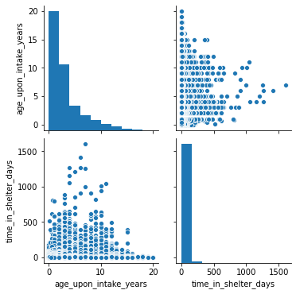

```python
sb.pairplot(dacc.iloc[:,[1,2]])
dacc['age_upon_intake_years'].corr(dacc['time_in_shelter_days'])
```

**Result: No correlation is present**

**3) Checking histograms and boxplots for continuous variables**

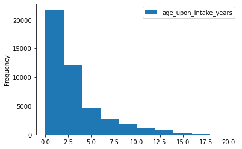

```python
dacc.loc[:,['age_upon_intake_years']].plot(kind='hist')
```

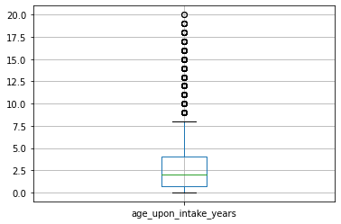

```python
dacc.boxplot(column='age_upon_intake_years')
```

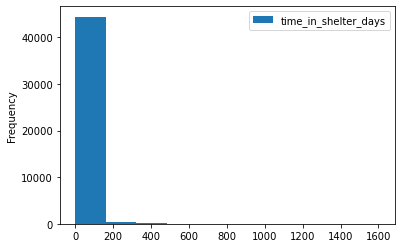

```python
dacc.loc[:,['time_in_shelter_days']].plot(kind='hist')
```

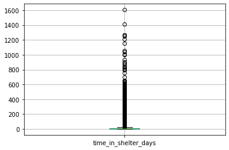

```python
dacc.boxplot(column='time_in_shelter_days')
```

**Result: There is clear indication that there are considerable outliers in time in shelter by examining the histograms and boxplots.**

**4) Defining Quartiles and IQR values to use later to eliminate outliers**

**Filtering out outliers by selecting 1.5 times the IQR in both directions**

```python
from scipy import stats
Q1 = dacc.loc[:,['time_in_shelter_days']].quantile(0.25)
Q3 = dacc.loc[:,['time_in_shelter_days']].quantile(0.75)
IQR = Q3 - Q1
print(IQR)
dacc.loc[:,['time_in_shelter_days']].shape
```

```
time_in_shelter_days    9.030903
dtype: float64
```

```
(45027, 1)
```

```python
daccOut1 = dacc.loc[dacc.time_in_shelter_days > float(Q1 - 1.5 * IQR)]

daccOut = daccOut1.loc[dacc.time_in_shelter_days < float(Q3 + 1.5 * IQR)]



daccOut.loc[:,['time_in_shelter_days']].shape
```

```
(38781, 1)
```

**Removing outliers**

```python
dacc = daccOut
```

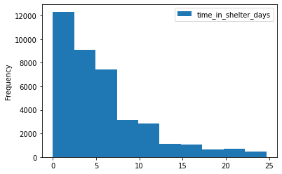

```python
dacc.loc[:,['time_in_shelter_days']].plot(kind='hist')
```

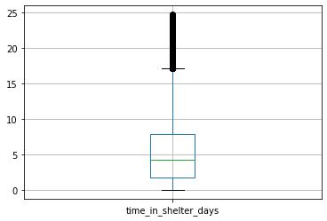

```python
boxplot = dacc.boxplot(column='time_in_shelter_days')
```

```python
dacc = daccOut
```

```python
dacc
```

|  | outcome_type | age_upon_intake_years | time_in_shelter_days | breed_Affenpinscher | breed_Afghan Hound | breed_Airedale Terrier | breed_Akbash | breed_Akita | breed_Alaskan Husky | breed_Alaskan Malamute | ... | intake_month_10 | intake_month_11 | intake_month_12 | intake_weekday_Friday | intake_weekday_Monday | intake_weekday_Saturday | intake_weekday_Sunday | intake_weekday_Thursday | intake_weekday_Tuesday | intake_weekday_Wednesday |
| --- | --- | --- | --- | --- | --- | --- | --- | --- | --- | --- | --- | --- | --- | --- | --- | --- | --- | --- | --- | --- | --- |
| 0 | Return to Owner | 10.000000 | 0.588194 | 0 | 0 | 0 | 0 | 0 | 0 | 0 | ... | 0 | 0 | 1 | 0 | 0 | 0 | 0 | 1 | 0 | 0 |
| 1 | Return to Owner | 7.000000 | 1.259722 | 0 | 0 | 0 | 0 | 0 | 0 | 0 | ... | 0 | 0 | 1 | 1 | 0 | 0 | 0 | 0 | 0 | 0 |
| 2 | Return to Owner | 6.000000 | 1.113889 | 0 | 0 | 0 | 0 | 0 | 0 | 0 | ... | 0 | 0 | 0 | 1 | 0 | 0 | 0 | 0 | 0 | 0 |
| 3 | Transfer | 10.000000 | 4.970139 | 0 | 0 | 0 | 0 | 0 | 0 | 0 | ... | 0 | 0 | 0 | 0 | 0 | 0 | 0 | 0 | 0 | 1 |
| 4 | Return to Owner | 16.000000 | 0.119444 | 0 | 0 | 0 | 0 | 0 | 0 | 0 | ... | 0 | 1 | 0 | 0 | 0 | 1 | 0 | 0 | 0 | 0 |
| ... | ... | ... | ... | ... | ... | ... | ... | ... | ... | ... | ... | ... | ... | ... | ... | ... | ... | ... | ... | ... | ... |
| 45358 | Transfer | 0.164384 | 4.075000 | 0 | 0 | 0 | 0 | 0 | 0 | 0 | ... | 0 | 0 | 0 | 0 | 0 | 0 | 0 | 1 | 0 | 0 |
| 45359 | Return to Owner | 0.657534 | 5.106944 | 0 | 0 | 0 | 0 | 0 | 0 | 0 | ... | 0 | 0 | 0 | 0 | 0 | 0 | 0 | 1 | 0 | 0 |
| 45360 | Return to Owner | 1.000000 | 0.104861 | 0 | 0 | 0 | 0 | 0 | 0 | 0 | ... | 0 | 0 | 0 | 0 | 0 | 0 | 0 | 1 | 0 | 0 |
| 45361 | Return to Owner | 0.410959 | 1.762500 | 0 | 0 | 0 | 0 | 0 | 0 | 0 | ... | 0 | 0 | 0 | 0 | 0 | 0 | 0 | 1 | 0 | 0 |
| 45362 | Euthanasia | 10.000000 | 0.813889 | 0 | 0 | 0 | 0 | 0 | 0 | 0 | ... | 0 | 0 | 0 | 0 | 0 | 0 | 0 | 1 | 0 | 0 |

38781 rows × 270 columns

**5) Feature Selection**

**Classifying 'Transfer','Euthanasia','Died','Missing','Disposal' to 0 as a "bad" outcome**

**Classifying 'Adoption','Return to Owner','Rto-Adopt' to 1 as a "good" outcome**

```python
from sklearn.model_selection import train_test_split

X = dacc.iloc[:, 1:272]
y = dacc.iloc[:, [0]]
y = y.iloc[:,0].replace(['Transfer','Euthanasia','Died','Missing','Disposal'], 0)
y = y.replace(['Adoption','Return to Owner','Rto-Adopt'], 1)

X_train , X_test , y_train, y_test = train_test_split(X, y, test_size=0.30, random_state=123, stratify=y)
```

**Running lasso regression on the data then using different C**

```python
from sklearn.feature_selection import SelectFromModel
from sklearn.linear_model import Lasso, LogisticRegression
from sklearn.ensemble import RandomForestClassifier
from sklearn.tree import DecisionTreeClassifier
from sklearn.model_selection import cross_val_score
```

**Running a lasso regression and using cross validation on different models and using the average to evaluate the accuracy**

```python
C = [.001,.01,.1,1,10,100]  # Different values for C, which acts as a regulator. High values risk overfitting, low values underfitting
                            # The higher the C, the less attributes Lasso will remove
for c in C:
    print(f'C = {c}\n')
    model = SelectFromModel(LogisticRegression(C=c,penalty='l1',solver='liblinear')) # SelectModel gives an easy way to visualize features selected by Lasso. Lasso is selected by penalty = l1
    model.fit(X_train, y_train)
    selected_feat = X_train.columns[(model.get_support())] # Gets features that have not been removed by lasso
    X_train_selected= X_train[selected_feat] # Tweak dataset with features selected by Lasso
    X_test_selected = X_test[selected_feat]
    print(f'Number of attributes: {X_train_selected.shape[1]}\n')
    # Run 3 classifiers to see how model is affected by different C's
    rf = RandomForestClassifier(max_depth=4, random_state=0)
    dt = DecisionTreeClassifier(random_state=0, max_depth=5)
    lgr = LogisticRegression(max_iter=1000)


    scores1 = np.mean(cross_val_score(dt, X_train_selected, y_train.values.ravel(), cv=10))
    print('DT Score: ', scores1, "\n")
    scores2 = np.mean(cross_val_score(rf, X_train_selected, y_train.values.ravel(), cv=10))
    print('RF Scores: ', scores2, "\n")
    scores3 = np.mean(cross_val_score(lgr, X_train_selected, y_train.values.ravel(), cv=10))
    print('LGR Score: ', scores3, "\n")
```

```
C = 0.001

Number of attributes: 2

DT Score:  0.7720838405593531

RF Scores:  0.7722311973519748

LGR Score:  0.7651216324602939

C = 0.01

Number of attributes: 12

DT Score:  0.7819566099523513

RF Scores:  0.7748100905067645

LGR Score:  0.7651587091555823

C = 0.1

Number of attributes: 59

DT Score:  0.7821774144297831

RF Scores:  0.7662639665278326

LGR Score:  0.7705734809344088

C = 1

Number of attributes: 173

DT Score:  0.7822510928260937

RF Scores:  0.7563547582889892

LGR Score:  0.771015469884685

C = 10

Number of attributes: 244

DT Score:  0.7822142604135707

RF Scores:  0.7537759872755821

LGR Score:  0.7707576294257591

C = 100

Number of attributes: 259

DT Score:  0.7822510792548291

RF Scores:  0.7525603140933512

LGR Score:  0.7706471321881899
```

**Result: The best C looks like .01 which leaves us 12 attributes**

**6) Using the best the C score and running cross validation and showing all the values this time**

```python
c = .01
print(f'C = {c}\n')
model = SelectFromModel(LogisticRegression(C=c,penalty='l1',solver='liblinear')) # SelectModel gives an easy way to visualize features selected by Lasso. Lasso is selected by penalty = l1
model.fit(X_train, y_train)
selected_feat = X_train.columns[(model.get_support())] # Gets features that have not been removed by lasso
X_train_selected= X_train[selected_feat] # Tweak dataset with features selected by Lasso
X_test_selected = X_test[selected_feat]
print(f'Number of attributes: {X_train_selected.shape[1]}\n')
# Run 3 classifiers to see how model is affected by different C's
rf = RandomForestClassifier(max_depth=4, random_state=0)
dt = DecisionTreeClassifier(random_state=0, max_depth=5)
lgr = LogisticRegression(max_iter=1000)


scores1 = (cross_val_score(dt, X_train_selected, y_train.values.ravel(), cv=10))
print('DT Score: ', scores1, "\n")
scores2 = (cross_val_score(rf, X_train_selected, y_train.values.ravel(), cv=10))
print('RF Scores: ', scores2, "\n")
scores3 = (cross_val_score(lgr, X_train_selected, y_train.values.ravel(), cv=10))
print('LGR Score: ', scores3, "\n")
```

```
C = 0.01

Number of attributes: 12

DT Score:  [0.78453039 0.78453039 0.7893186  0.7771639  0.78047882 0.78158379
 0.78518791 0.78224024 0.77855564 0.77597642]

RF Scores:  [0.77937385 0.77974217 0.77200737 0.77605893 0.77458564 0.77237569
 0.77376566 0.77634488 0.7733972  0.77044952]

LGR Score:  [0.76721915 0.76685083 0.76611418 0.76574586 0.76279926 0.76390424
 0.76123803 0.76713338 0.76529108 0.76529108]
```

**Result: Looking across the validation scores array, we are confident that the model is not overfitting since the variation is minimal**

**This is also supported by our chosen low value of C - to minimize our risk of overfitting**